# Age: Assortativity and associations to cluster size and infector probability

Stephane

29 June 2016

```r
library(knitr)
read_chunk('assort_matrix.R')
read_chunk('age_regressions.R')
```

```r
detail_knitr <- TRUE
```

- I compare SA with both UCSD cluster and *distance neighborhood* at 4 thresholds
- Here are mostly figures (detail_knitr = TRUE)

### Assortativity

- Assortativity matrices for each sims in `age` folder
  - analyzed in `assort_matrix.R`
- UCSD cluster size, neighborhood size, outdegrees, indegrees in `cw_Baseline0.rds` file
- Age matrices computed on HPC in `data/simulations2/age/`

```r
library(reshape2)
library("ggplot2")
# theme_set(theme_bw())
library(scales)
library(gridExtra)
require(lattice)
##- aggregate matrix cluster in a list by threshold
##- ucsd cluster
ag_amat_cl <- lapply(list_agmat_cl, function(x) Reduce('+', x))

##-  age matrix of infector probs
load(fn.mat[1])
# str(ll)
ag_amat_sa <- ll$agemat_sa
for (i in 2:length(fn.mat)){
  load(fn.mat[i])
  ag_amat_sa <- ag_amat_sa + ll$agemat_sa
}

##- nbrhood size
ag_amat_nb <- rep(list(matrix(0,4,4)), length(ll[["agemat_cl"]]))
options(scipen = -100)
names(ag_amat_nb) <- as.character( as.numeric(names(ll[["agemat_cl"]])) ) # treshold names
options(scipen = 0)
for (i in 1:length(fn.mat)){
  load(fn.mat[i])
  for (j in 1:length(ll[["agemat_cl"]]) ){
    ag_amat_nb[[j]] <- ag_amat_nb[[j]] + ll[["agemat_cl"]][[j]][["agemat2"]]
  }
}
```

```r
##- Newman's assortativity coefficient
mat2assortCoef <- function(mat){
  mat <- mat / sum(mat )
  rs <- rowSums(mat)
  cs <- colSums(mat)
  sum(diag(mat) - rs*cs) / (1 - sum(rs*cs))
}
##- Assortivity matrix (difference from null expectation under random linking)
mat2assortmat <- function(mat){
  rs <- rowSums(mat)
  cs <- colSums(mat)
  s <- sum(mat)
  M <- matrix(0, nrow=nrow(mat), ncol = ncol(mat))
  A <- matrix(0, nrow=nrow(mat), ncol = ncol(mat))
  k <- nrow(mat)
  for (i in 1:k) for (j in 1:k){
    M[i,j] <- rs[i] * cs[j] / s
    A[i,j] <- ( mat[i,j] - M[i,j] )/ M[i,j]
  }
  A
}
```

```r
assor_mat_sa <- mat2assortmat(ag_amat_sa)
assor_mat_nb <- lapply(ag_amat_nb, mat2assortmat)
assor_mat_cl <- lapply(ag_amat_cl, mat2assortmat)
```

```r
coef_mat_sa <- mat2assortCoef(ag_amat_sa)
coef_mat_nb <- lapply(ag_amat_nb, mat2assortCoef)
coef_mat_cl <- lapply(ag_amat_cl, mat2assortCoef)
```

##### Assortativity of infector probs by age

```r
##- SA
# print("Assortativity of infector probs by age")
p_sa <- levelplot( assor_mat_sa, col.regions = heat.colors,
           main = 'SA',
           sub = paste('r = ', round(coef_mat_sa,2)),
           xlab = '', ylab = '')

# p_sa
```

##### Assortativity of neighborhood size by age by distance threshold

```r
##- neighborhood
plots_grid <- function(mat, coef){
  ## empty list of plots
  p <-  vector("list", length(mat))
  # par(mfrow = c(length(a)/2, 2), bty = 'n') # useless for lattice
  for (i in 1:length(mat)){
    p[[i]] <- levelplot( mat[[i]], col.regions = heat.colors, main = names(mat)[i], sub = paste('r = ', round(coef[[i]],2)), xlab = '', ylab = '')
  }
  return(p)
}

p_nb <- plots_grid(assor_mat_nb[3:6], coef_mat_nb[3:6])
# print("Assortativity of neighborhood size by age")
##- plot
# do.call(grid.arrange, c(p_nb, ncol = ceiling(length(p_nb)/2)) )
```

##### Assortativity of cluster size by age by distance threshold

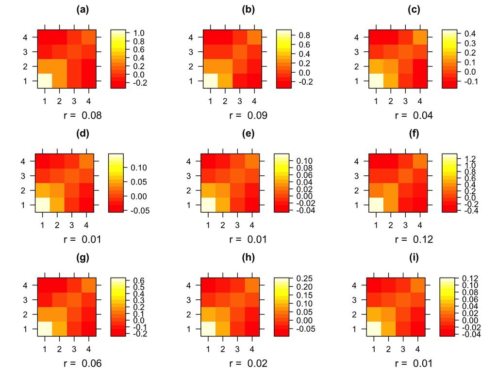

```r
##- ucsd
p_cl <- plots_grid(assor_mat_cl[3:6], coef_mat_cl[3:6])
# print("Assortativity of cluster size by age")
# do.call(grid.arrange, c(p_cl, ncol = ceiling(length(p_cl)/2)) )

##- arrange all plots
all_p <- c(list(p_sa), p_cl, p_nb)
##- rename main title with a,b,c and r newman, small text plain, par.settings
theme1 <-
list(layout.heights =
       list(top.padding = 1,
            main.key.padding = .5,
            key.axis.padding = 0,
            axis.xlab.padding = 0,
            xlab.key.padding = 0,
            key.sub.padding = .5,
            bottom.padding = 1),
     layout.widths =
       list(left.padding = .5,
            key.ylab.padding = 0,
            ylab.axis.padding = 0,
            axis.key.padding = 0,
            right.padding = .5))

all_p <- lapply(1:length(all_p), function(x){
  all_p[[x]]$main <- list(label = paste0('(', letters[x], ')'), cex = 1)
  all_p[[x]]$sub <- list(label = all_p[[x]]$sub, cex = 1, font = 1)
  all_p[[x]]$par.settings <- theme1
  return( all_p[[x]])
}   )

do.call(grid.arrange, c( all_p, ncol = 3 ))
```

- Caption: (a) SA; (b to e) ucsd cluster at 0.001, 0.005, 0.015, 0.05; (f to i) neighborhood at 0.001, 0.005, 0.015, 0.05
- Assortativity mostly detected at younger age
- And at lower threshold

```r
deme2age <- function(deme){as.numeric( substr(regmatches( deme , regexpr( '\\.age[0-9]', deme )), 5,5) ) }
deme2stage <- function(deme){as.numeric( substr(regmatches( deme , regexpr( 'stage[0-9]', deme )), 6,6) ) }

##- run model
if(FALSE){
  require(phydynR)
source('model0.R')
o <- ode(y=y0, times=times_day, func=dydt, parms=list()  , method = 'adams')
tfgy <- .tfgy( o )
FF <- tfgy[[2]][[length(times_day)]]
fmat <- matrix(0, nrow = 4, ncol = 4)
for (k in 1:120) for (l in 1:120){
  fmat[ deme2age( DEMES[k] ), deme2age(DEMES[l]) ] <- fmat[ deme2age( DEMES[k] ), deme2age(DEMES[l]) ] + FF[k,l]
}
} else {
  # saveRDS(fmat, file = "data/sim_ucsd_results2/model0.agemat.rds")
  fmat <- readRDS(file = "data/sim_ucsd_results2/model0.agemat.rds")
}
##- True assortativity in baseline simulation
BASELINE_ASSRTCOEF <- mat2assortCoef( fmat )
print(BASELINE_ASSRTCOEF)
```

```
## [1] 0.3090419
```

```r
##- "true" heatmap
# levelplot( mat2assortmat( fmat ), col.regions = heat.colors)
```

```r
# compute assort coef for each sim; plot results with 'truth'
assrt_coefs_sa <- vector(mode="numeric", length = length(fn.mat))
for (i in 1:length(fn.mat)){
  load(fn.mat[i])
  assrt_coefs_sa[i] <- mat2assortCoef(ll$agemat_sa)
}

##- For neighborhood
##- empty list of 4 matrices
assrt_coefs_nb <- rep(list(vector(mode="numeric", length = length(fn.mat))), length(ll[["agemat_cl"]]))
options(scipen = -100)
names(assrt_coefs_nb) <- as.character(as.numeric ( names(ll[["agemat_cl"]]) ) ) # treshold names
options(scipen = 0)

##- loop
for (i in 1:length(fn.mat)){
  load(fn.mat[i])
  for (j in 1:length(ll[["agemat_cl"]]) ){
    assrt_coefs_nb[[j]][i] <-   mat2assortCoef(ll[["agemat_cl"]][[j]][["agemat2"]])
  }
}

##- For ucsd
##- empty list of 4 matrices
assrt_coefs_cl <-  lapply(list_agmat_cl, function(x) sapply(x, mat2assortCoef))
```

```r
##- transform in df
df <- cbind("SA" = assrt_coefs_sa,
            "NB" = do.call(cbind.data.frame, assrt_coefs_nb),
            "CL" = do.call(cbind.data.frame, assrt_coefs_cl) )
# str(df)
## with reshape2
a <- melt(df)
```

```r
## extra columns for facets
a$method <- substr(a$variable, 1, 2)
##- add '' for threshold of SA method
a$thr <- c(rep('NA', length(a[a$method == 'SA', 'method'])), regmatches(a$variable, regexpr("\\d\\..*|\\d*e[-+]?.*",  a$variable)) )
# table(a$thr)
# str(a)
##- keep only 4 thersholds
a <-a[!(a$thr %in% c('1e-05','1e-04')),]
##- force scientific notation
fancy_scientific <- function(l) {
  if( is.na(as.numeric(l)) ) parse(text = l) else {
  # turn in to character string in scientific notation
  l <- format(l, scientific = TRUE)
  l <- gsub("0e\\+00","0",l)
  # quote the part before the exponent to keep all the digits
  l <- gsub("^(.*)e", "'\\1'e", l)
  # remove + after exponent, if exists. E.g.: (3x10^+2 -> 3x10^2)
  l <- gsub("e\\+","e",l)
  # turn the 'e+' into plotmath format
  l <- gsub("e", "%*%10^", l)
  # convert 1x10^ or 1.000x10^ -> 10^
  l <- gsub("\\'1[\\.0]*\\'\\%\\*\\%", "", l)
  # return this as an expression
  parse(text=l)
  }
}
```

##### Distribution of estimated assortativity coefficient by method

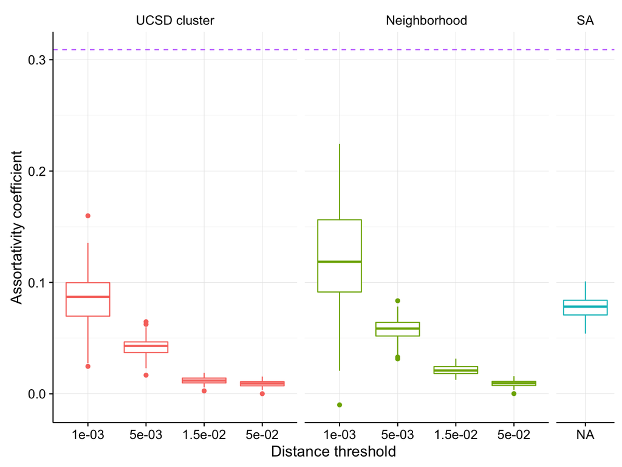

```r
library(cowplot)
bp1 <- ggplot(a, aes(reorder(thr, as.numeric(thr)), value, color = method)) + geom_boxplot()
bp2 <- bp1  +
  facet_grid(~ method, scales = "free", space = "free", labeller=labeller(method = c(SA = "SA", CL = "UCSD cluster", NB = "Neighborhood")))  +
  geom_hline(aes(yintercept = BASELINE_ASSRTCOEF, colour = "true coefficient"), linetype = "dashed") +
  xlab("Distance threshold") + ylab("Assortativity coefficient")

  # theme(legend.position="top", legend.title=element_blank(), strip.text.x = element_text(size = 12)) + guides(fill=FALSE) +
bp3 <- bp2 + theme(legend.position="none") +
  background_grid() + # + theme_bw()
theme(strip.background = element_blank())
bp3
```

```r
# bp2 %+% a[a$thr != '1e-05',] + scale_x_discrete(labels = fancy_scientific) + theme(legend.position="none") +
# background_grid() + theme(strip.background = element_blank())
```

##### Distribution of estimated assortativity coefficient (log) by method

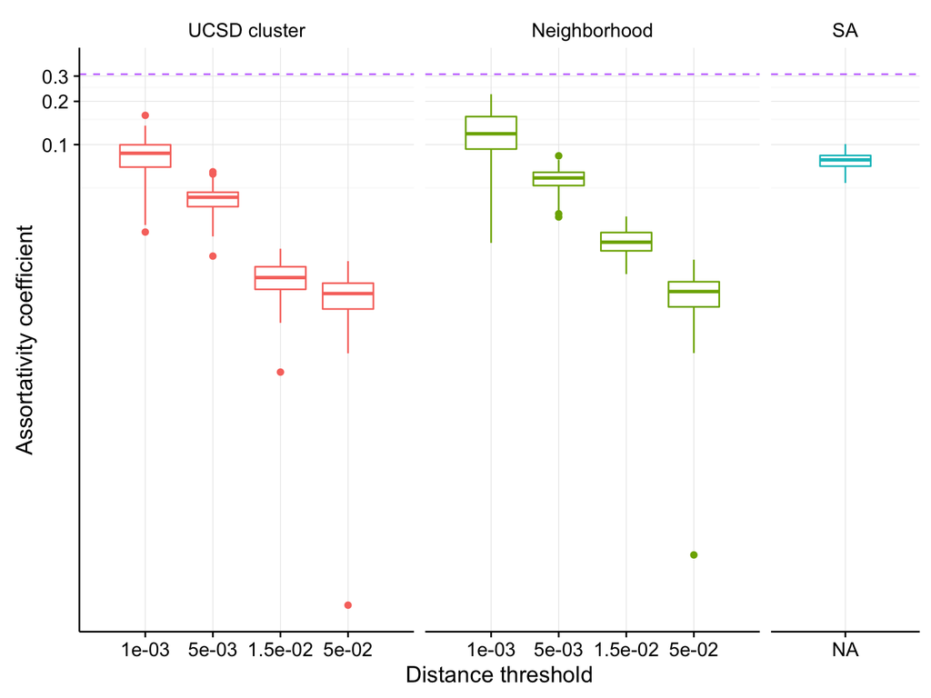

```r
## With scale that adapts to transformation
bp3 %+% a[a$value >= 0,] + coord_trans(y = "log")
```

- As Erik found, all methods underestimate true assortativity
- At lowest threshold, age assortativity into cluster is closer to truth than for SA but less precisely estimated

### Regressions

```r
## age vs sizes, degrees at different thr
cw_Baseline0 <- readRDS(file = "data/sim_ucsd_results2/list.sim.clus-outdeg.Baseline0.rds" )
names(cw_Baseline0)
```

```
## [1] "SA"    "1e-05" "1e-04" "0.001" "0.005" "0.015" "0.05"
```

```r
cw_Baseline0 <- cw_Baseline0[c('SA', '0.001', '0.005', '0.015', '0.05')]

## change structure in long table (!!!! first few for speed)
.n <- 10
.m <- sample(1:100, .n)
c <- lapply(cw_Baseline0,
            function(x) do.call(rbind, x[.m]))

options(scipen = -100)
names(c)[-1] <- as.character( as.numeric(names(c)[-1]) )
options(scipen = 0)
# rm(cw_Baseline0)

# head(c[[2]])
# names(c)
# str(c)
# lapply(c, function(x) mean(x$nbhsize))
```

```r
winsorize <- function (x, fraction=.05) {
  if(length(fraction) != 1 || fraction < 0 ||
     fraction > 0.5) {
    stop("bad value for 'fraction'")
  }
  lim <- quantile(x, probs=c(fraction, 1-fraction), na.rm = TRUE)
  x[ x < lim[1] ] <- lim[1]
  x[ x > lim[2] ] <- lim[2]
  x
}

c_win <- lapply(c, function(x){
  if ( any(grepl('outdegree', names(x))) ) {
    x[, 'outdegree'] <- winsorize( x[, 'outdegree'] )
    return(x)
  } else {
    x[, 'size'] <- winsorize( x[, 'size'] )
    x[, 'nbhsize'] <- winsorize( x[, 'nbhsize'] )
    return(x)
  }
})
```

```r
molten <- function(a){
  .sa <- melt( a[[1]][, -c(6)],  measure.vars = 5)
# head(sa)
.thr <- melt(a[-1],  measure.vars = c(6, 7))
# head(thr)
tot <- rbind( cbind(.sa, "L1" = 'NA'), .thr[,-c(2,6)])
# head(tot)
return(tot)
}

tot <- molten(c)
tot_win <- molten(c_win)
```

```r
tapply(tot$value, list(tot$L1, tot$variable), function(x) max(x, na.rm = T))
```

```
##         outdegree size nbhsize
## NA       4.057465   NA      NA
## 1e-03          NA   11       6
## 5e-03          NA   32      20
## 1.5e-02        NA   71      52
## 5e-02          NA   82      81
```

```r
tapply(tot_win$value, list(tot_win$L1, tot_win$variable), function(x) max(x, na.rm = T))
```

```
##         outdegree size nbhsize
## NA      0.9887034   NA      NA
## 1e-03          NA    2       0
## 5e-03          NA    7       4
## 1.5e-02        NA   30      15
## 5e-02          NA   36      35
```

##### Distribution of outdegrees and cluster sizes at distance threshold = 0.015 by age category

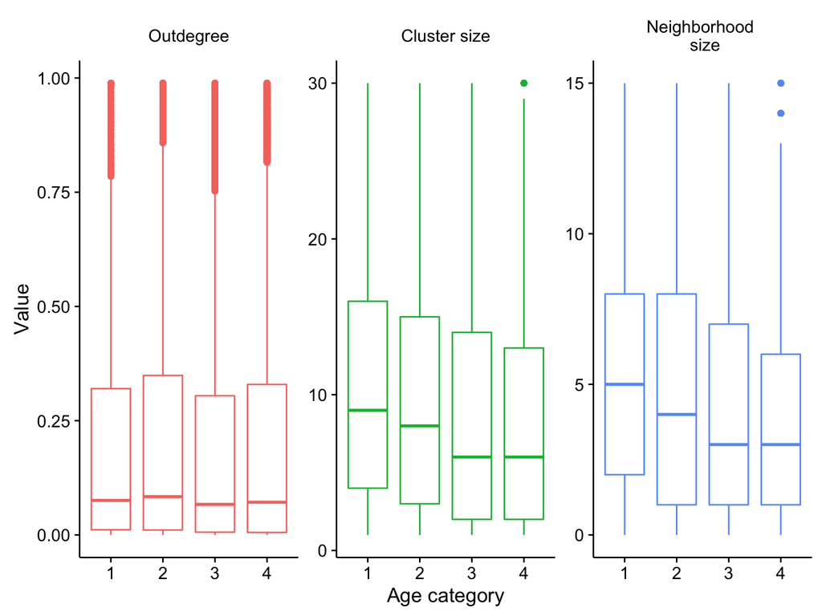

```r
p <- ggplot(tot, aes(x = factor(age), y = value, colour = variable), outlier.colour= alpha("black", 0.1)) + geom_boxplot() + theme(legend.position="none", legend.title = element_blank(), strip.text.x = element_text(size = 12))
# p2 <- p + facet_wrap(~ variable + L1, nrow = 4, scales = "free_y")
# p2
# p2 %+% tot_win
# p2 + geom_jitter(alpha = 0.1)
#
# p3 <- ggplot(tot, aes(factor(age), value, fill = variable)) + geom_boxplot()
# p4 <- p3 + facet_wrap(~ variable + L1, nrow = 1, scales = "free_y")
# p4
# p4 %+% tot_win

##- at 0.015 only, winsorized
# p %+% tot[tot$L1 %in% c('NA','0.015'),] + facet_wrap(~ variable, nrow = 1, scales = "free_y")
p %+% tot_win[tot_win$L1 %in% c('NA','1.5e-02'),] + facet_wrap(~ variable, nrow = 1, scales = "free_y", labeller=labeller(variable = c(outdegree = "Outdegree", size = "Cluster size", nbhsize = "Neighborhood \n size"))) +
  theme(strip.background = element_blank()) +
  xlab("Age category") + ylab("Value")
```

```r
##- summarize regression on bootstrap

source('functions.R')
compare.reg.bs2
```

```
## function (ls, reg = lm, y = "size", model, alpha = 0.05, details = FALSE,
##     ...)
## {
##     coef <- lapply(ls, function(x) {
##         lapply(x, function(x) {
##             if (y %in% names(x)) {
##                 full.model <- sub("y", paste("scale(", y, ")",
##                   sep = ""), model)
##             }
##             else if ("outdegree" %in% names(x)) {
##                 full.model <- sub("y", "scale(outdegree)", model)
##             }
##             else stop("cannot find y")
##             coef(summary(reg(formula = full.model, data = x,
##                 ...)))
##         })
##     })
##     pvalue <- lapply(coef, function(x) {
##         sapply(x, function(x) {
##             identity(x[, 4])
##         })
##     })
##     if (details) {
##         sum.signif <- sapply(pvalue, function(x) {
##             apply(x, 1, function(x) sum(x < alpha)/length(x))
##         })
##     }
##     xs <- trimws(unlist(strsplit(model, "[~+]")))
##     title <- paste("p-values for all categories of", xs[2], "explaining outdegree and",
##         y)
##     p_x1 <- sapply(pvalue, function(x) {
##         sum(x[grepl(xs[2], rownames(x), fixed = TRUE) & !grepl(":",
##             rownames(x), fixed = TRUE), ] < alpha)/length(x[grepl(xs[2],
##             rownames(x), fixed = TRUE) & !grepl(":", rownames(x),
##             fixed = TRUE), ])
##     })
##     sum.signif_x <- list(title, p_x1)
##     param <- lapply(coef, function(x) {
##         sapply(x, function(x) {
##             identity(x[, 1])
```

[output cut: 28 more lines]

```
##         }
##         else {
##             return(list(model = model, sum.signif_x, `mean r.squared` = mean.r2))
##         }
##     }
##     else {
##         if (details) {
##             return(list(model = model, `mean parameter` = mean.parms,
##                 `signif pvalue` = sum.signif, sum.signif_x))
##         }
##         else {
##             return(list(model = model, sum.signif_x))
##         }
##     }
## }
```

```r
model1 <- "y ~ factor(age)"
model2 <- "y ~ factor(age) + factor(stage) + factor(age)*factor(stage)"
```

##### Regressing age without stage interaction

```r
m1 <- compare.reg.bs2(ls = cw_Baseline0, reg = lm, y = 'size', model = model1)
m1
```

```
## $model
## [1] "y ~ factor(age)"
##
## [[2]]
## [[2]][[1]]
## [1] "p-values for all categories of factor(age) explaining outdegree and size"
##
## [[2]][[2]]
##         SA      0.001      0.005      0.015       0.05
## 0.03333333 0.57000000 0.83333333 0.90000000 0.92000000
##
##
## $`mean r.squared`
##       SA    0.001    0.005    0.015     0.05
## 0.000616 0.002300 0.005650 0.005840 0.005370
```

```r
m1nb <- compare.reg.bs2(ls = cw_Baseline0, reg = lm, y = 'nbhsize', model = model1)
m1nb
```

```
## $model
## [1] "y ~ factor(age)"
##
## [[2]]
## [[2]][[1]]
## [1] "p-values for all categories of factor(age) explaining outdegree and nbhsize"
##
## [[2]][[2]]
##         SA      0.001      0.005      0.015       0.05
## 0.03333333 0.30000000 0.81666667 0.93666667 0.92000000
##
##
## $`mean r.squared`
##       SA    0.001    0.005    0.015     0.05
## 0.000616 0.001050 0.006470 0.008780 0.005380
```

- Significant associations of size and age
  - At threshold 0.015, UCSD cluster would find 90%
  - At threshold 0.015, neighborhood would find 94%
  - SA would find 3%

##### Regressing age by cluster size with stage interaction

```r
m2 <- compare.reg.bs2(ls = cw_Baseline0, reg = lm, y = 'size', model = model2)
m2
```

```
## $model
## [1] "y ~ factor(age) + factor(stage) + factor(age)*factor(stage)"
##
## [[2]]
## [[2]][[1]]
## [1] "p-values for all categories of factor(age) explaining outdegree and size"
##
## [[2]][[2]]
##        SA     0.001     0.005     0.015      0.05
## 0.0000000 0.2733333 0.2333333 0.2733333 0.2633333
##
##
## $`mean r.squared`
##     SA  0.001  0.005  0.015   0.05
## 0.2270 0.0353 0.0422 0.0223 0.0184
```

##### Regressing age by neighborhood size with stage interaction

```r
m3 <- compare.reg.bs2(ls = cw_Baseline0, reg = lm, y = 'nbhsize', model = model2)
m3
```

```
## $model
## [1] "y ~ factor(age) + factor(stage) + factor(age)*factor(stage)"
##
## [[2]]
## [[2]][[1]]
## [1] "p-values for all categories of factor(age) explaining outdegree and nbhsize"
##
## [[2]][[2]]
##        SA     0.001     0.005     0.015      0.05
## 0.0000000 0.2833333 0.2600000 0.2233333 0.2700000
##
##
## $`mean r.squared`
##     SA  0.001  0.005  0.015   0.05
## 0.2270 0.0222 0.0644 0.0439 0.0186
```

- Significant associations of size and age (when adjusting for stage)
  - At threshold 0.015, UCSD cluster would find 27%
  - At threshold 0.015, neighborhood would find 22%
  - SA would find 0%